# Cyclistic

Carlso

2025-03-26

# Cyclistic

Un programa de bicicletas compartidas iniciado en 2016 incluye 5,800 bicicletas y 600 estaciones. Cyclistic se destaca por ofrecer también bicicletas reclinadas, triciclos manuales y bicicletas de carga que ofrecen un uso más inclusivo de las bicicletas compartidas para las personas con discapacidad y los ciclistas que no pueden utilizar una bicicleta estándar de dos ruedas

- La mayoría de los ciclistas eligen las bicicletas tradicionales, alrededor de un 8% de los ciclistas usan las opciones asistidas.
- Los usuarios de Cyclistic son más propensos a utilizar la bicicleta para recreación, pero alrededor del 30% la utiliza para ir al trabajo cada día.
- 5,824 bicicletas georreferenciadas y bloqueadas en una red de 692 estaciones en toda Chicago. Las bicicletas se pueden desbloquear desde una estación y devolverse en cualquier otra estación del sistema en cualquier momento

Cyclistic se basaba en la construcción de un reconocimiento de marca general y en atraer a amplios segmentos de consumidores. Uno de los enfoques que ayudó a hacer esto posible fue la flexibilidad de sus planes de precios: pases de un solo viaje, pases de un día completo y membresías anuales. A los clientes que compran pases de un solo viaje o pases de un día completo se los llama ciclistas ocasionales. Los clientes que compran membresías anuales se llaman miembros de Cyclistic.

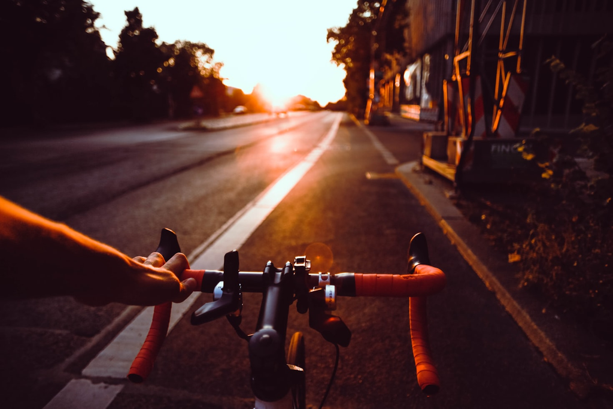

Bike

Los analistas financieros de Cyclistic llegaron a la conclusión de que los miembros anuales son mucho más rentables que los ciclistas ocasionales. Aunque la flexibilidad de precios ayuda a Cyclistic a atraer más clientes, Moreno cree que maximizar el número de miembros anuales será clave para el crecimiento futuro. En lugar de crear una campaña de marketing que apunte a todos los clientes nuevos, Moreno cree que hay muchas posibilidades de convertir a los ciclistas ocasionales en miembros. Ella señala que los ciclistas ocasionales ya conocen el programa de Cyclistic y han elegido a Cyclistic para sus necesidades de movilidad.

Moreno estableció una meta clara: Diseñar estrategias de marketing orientadas a convertir a los ciclistas ocasionales en miembros anuales. Sin embargo, para hacer eso, el equipo de analistas de marketing necesita entender mejor cómo difieren los miembros anuales y los ciclistas ocasionales, por qué los ciclistas ocasionales comprarían una membresía y cómo los medios digitales podrían afectar sus tácticas de marketing. Moreno y su equipo están interesados en analizar los datos históricos de viajes en bicicleta de Cyclistic para identificar tendencias.

Datos obtenidos del siguiente sitio https://divvy-tripdata.s3.amazonaws.com/index.html

### El analisis se realiza del mes de Febrero de 2025

```
##  [1] "ride_id"            "rideable_type"      "started_at"
##  [4] "ended_at"           "start_station_name" "start_station_id"
##  [7] "end_station_name"   "end_station_id"     "start_lat"
## [10] "start_lng"          "end_lat"            "end_lng"
## [13] "member_casual"
```

```
##  [1] "ride_id"            "rideable_type"      "started_at"
##  [4] "ended_at"           "start_station_name" "start_station_id"
##  [7] "end_station_name"   "end_station_id"     "start_lat"
## [10] "start_lng"          "end_lat"            "end_lng"
## [13] "member_casual"      "tmi"                "dlat"
## [16] "dlng"               "distancia"
```

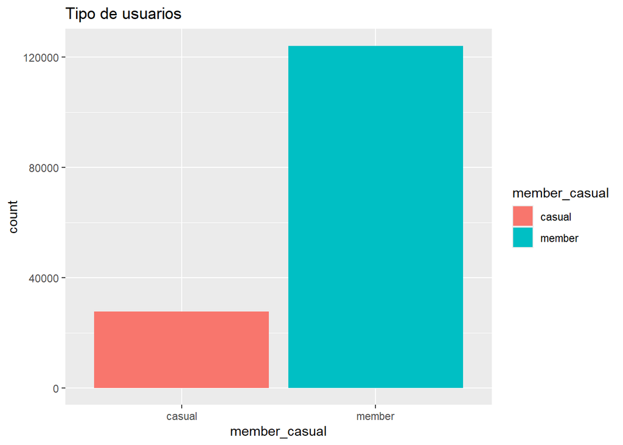

```
## [1] "De los 151880 viajes realizados,  18.27% [27754] son usuarios casuales y 81.73% [124126] son miembros"
```

Una vez realizado un analisis, respecto al tiempo transcurrido en cada viaje se destaca lo siguiente:

### Datos estadisticos usuarios casuales - tiempo de uso

```
##     Min.  1st Qu.   Median     Mean  3rd Qu.     Max. Stan.Dev
##     1.00     5.00     7.00    14.68    12.00  1500.00    68.76
```

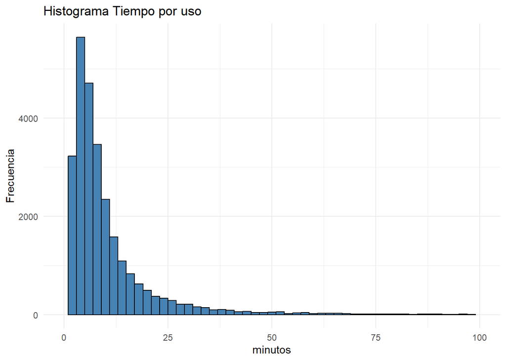

### Datos estadisticos usuarios con membresia - tiempo de uso

```
##     Min.  1st Qu.   Median     Mean  3rd Qu.     Max. Stan.Dev
##     1.00     4.00     7.00    10.09    12.00  1500.00    23.68
```

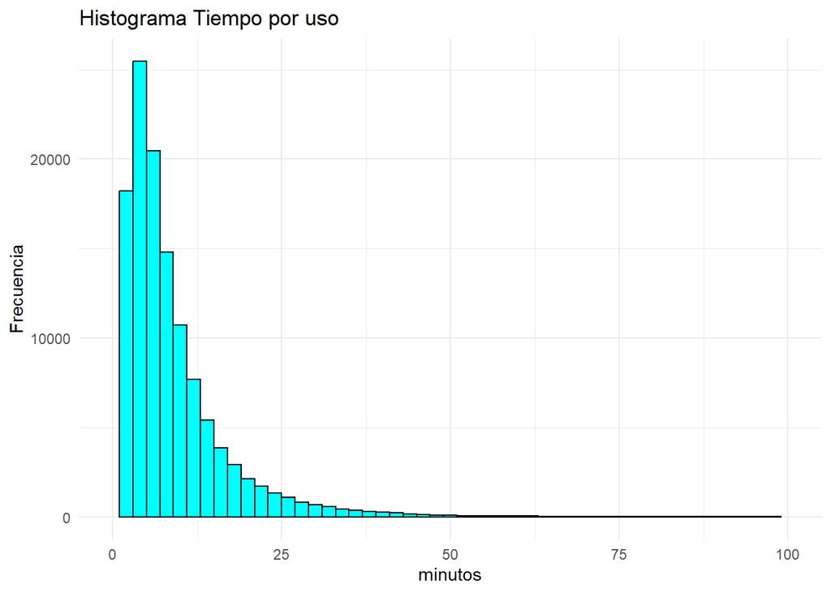

Tenemos algunos aspectos interesantes al analizar estos datos

*Los usuarios casuales tienen una media más alta y mayor dispersión en sus datos, lo que sugiere que algunos realizan recorridos muy largos.

*Los usuarios con membresía tienen recorridos más consistentes y menos variabilidad, indicando que usan el servicio de forma más estable y predecible.

### Datos estadisticos usuarios casuales - distancia recorrida

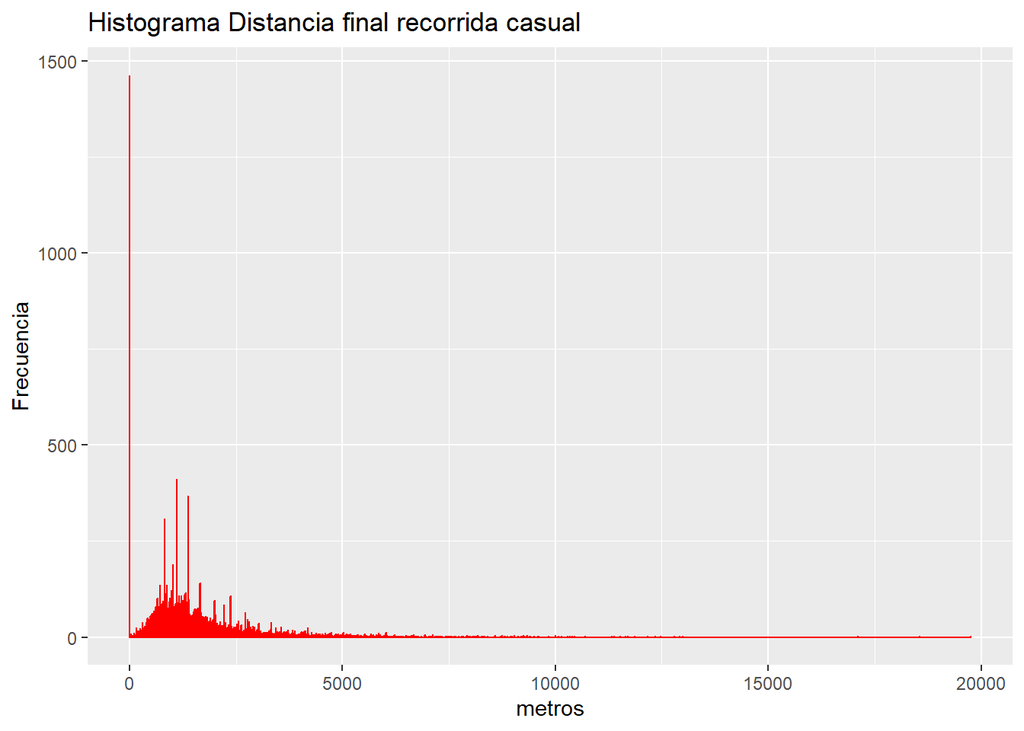

```
##     Min.  1st Qu.   Median     Mean  3rd Qu.     Max. Stan.Dev
##        0      836     1317     1713     2088    19750     1505
```

### Datos estadisticos usuarios membresia - distancia recorrida

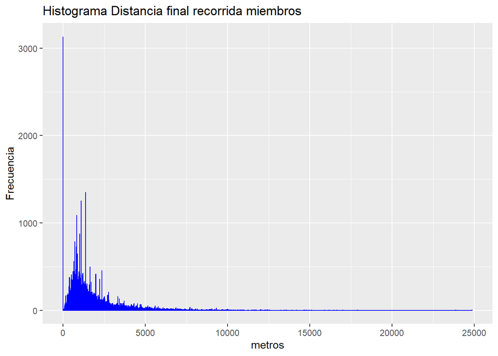

```
##     Min.  1st Qu.   Median     Mean  3rd Qu.     Max. Stan.Dev
##        0      828     1351     1865     2352    24866     1667
```

Tenemos algunos aspectos interesantes al analizar estos datos

- Los usuarios con membresía tienden a recorrer más distancia, lo que podría significar que usan el servicio con más frecuencia o para trayectos más largos.
- La variabilidad en miembros es mayor, lo que sugiere que algunos hacen trayectos cortos mientras que otros aprovechan el sistema para viajes largos.
- Los valores máximos más altos en miembros indican que este grupo probablemente incluya usuarios que dependen del servicio para viajes extensos.